# Effects of math anxiety on test scores

## Investigation Overview

In this investigation I wanted to see if there are impacts on test scores, specifically in math, when students feel anxiety around the subject and whether or not gender plays a role in both the amount of anxiety felt and effects on test scores.

## Dataset Overview

The dataset used was the PISA data from a 2012 study on students from 65 economies around the world. Student scores in math, reading, and science were captured as well as a multitude of answers about the students perception of their ability, anxiety they feel, etc.

```python
# import all packages and set plots to be embedded inline
import math
import numpy as np
import pandas as pd
from pandas.compat import StringIO, BytesIO
import matplotlib.pyplot as plt
import random
import seaborn as sb
import matplotlib.pyplot as plt
from matplotlib.pylab import rcParams
from matplotlib.lines import Line2D
rcParams['figure.figsize'] = 15, 12
%matplotlib inline
%config InlineBackend.figure_format = 'retina'
plt.style.use('fivethirtyeight')

# suppress warnings from final output
import warnings
warnings.simplefilter("ignore")
import tables
```

```python
# load in the dataset into a pandas dataframe
# it was necessary to use a HDFS file to retain our categorical data so we don't need to repeat the conversion process
pisa_df = pd.read_hdf('data/cleaned_pisa.h5', 'table')
print(pisa_df.shape)
pisa_df.head(10)
```

```
(970980, 10)
```

|  | country | gender | enjoy_math | ma_worry_that_difficult | msc_worry_not_good_at | ma_get_tense | ma_get_nervous | ma_feel_helpless | ma_worry_about_poor_grades | math_score |
| --- | --- | --- | --- | --- | --- | --- | --- | --- | --- | --- |
| 0 | Albania | Female | Agree | Agree | Disagree | Agree | Agree | Disagree | Disagree | 406.8469 |
| 1 | Albania | Female | Disagree | No Answer | No Answer | No Answer | No Answer | No Answer | No Answer | 486.1427 |
| 2 | Albania | Female | Agree | No Answer | No Answer | No Answer | No Answer | No Answer | No Answer | 533.2684 |
| 3 | Albania | Female | No Answer | No Answer | Strongly agree | Disagree | Agree | Disagree | Agree | 412.2215 |
| 4 | Albania | Female | Disagree | Strongly agree | Strongly agree | Agree | Strongly agree | Disagree | Agree | 381.9209 |
| 5 | Albania | Female | No Answer | Disagree | Disagree | Disagree | Agree | Disagree | Disagree | 396.3312 |
| 6 | Albania | Female | No Answer | Agree | Agree | Strongly agree | Disagree | Disagree | Agree | 438.0823 |
| 7 | Albania | Male | Agree | Disagree | Agree | Disagree | Disagree | Agree | Agree | 576.5773 |
| 8 | Albania | Female | Agree | Agree | Agree | Agree | Agree | Strongly disagree | Disagree | 434.1097 |
| 9 | Albania | Female | No Answer | Strongly disagree | Strongly disagree | Disagree | Disagree | Strongly disagree | Strongly disagree | 463.6314 |

```python
pisa_df.info(memory_usage='deep')
```

```
<class 'pandas.core.frame.DataFrame'>
Int64Index: 970980 entries, 0 to 485489
Data columns (total 10 columns):
country                       970980 non-null object
gender                        970980 non-null category
enjoy_math                    970980 non-null object
ma_worry_that_difficult       970980 non-null category
msc_worry_not_good_at         970980 non-null category
ma_get_tense                  970980 non-null category
ma_get_nervous                970980 non-null category
ma_feel_helpless              970980 non-null category
ma_worry_about_poor_grades    970980 non-null category
math_score                    970980 non-null float64
dtypes: category(7), float64(1), object(2)
memory usage: 143.1 MB
```

## Distribution of math scores

Examing the distribution of math scores we can see a standard distribuion of scores.

- mean score 469.62
- minimum 19.79
- 25% quartile 395.31
- 50% quartile 466.20
- 75% quartile 541.05
- maximum 962.22

```python
def scoreDistVis():
    # produce a histogram of the distribution of math scores in dataset
    binsize = 50

    plt.figure(figsize=[12, 5])
    bins = np.arange(0, pisa_df['math_score'].max()+binsize, binsize)
    sb.distplot(pisa_df.math_score, bins=bins, hist_kws={"ec":"k"})
    plt.xlabel('Math Score');
    plt.ylabel('Density');
    plt.title('Distribution of Math Test Scores')

    return
```

```python
def plotCat(data, cat, ylabel='', xlabel='', title=None):
    # use the supplied dataframe to generate a bar chart of categorical values
    base_color = sb.color_palette()[0]
    sb.countplot(data=data, x=cat, color=base_color)

    # add annotations
    n_points = data.shape[0]
    cat_counts = data[cat].value_counts()
    locs, labels = plt.xticks() # get current location of the ticks and labels

    # loop through each pair of loc and label
    for loc, label in zip(locs, labels):
        # get text property of label
        count = cat_counts[label.get_text()]
        if count < 100000:
            minus_per = math.ceil(count * .20) # the adjustment to text location differs based on total
        else:
            minus_per = math.ceil(count * .08)
        pct_string = '{:0.2f}%'.format(100*count/n_points)
        # print annotation just below top of bar
        plt.text(loc, count-minus_per, pct_string, ha='center', color='w', fontweight='bold')

    plt.xlabel(xlabel);
    plt.ylabel(ylabel);

    if title:
        plt.title(title);

    return
```

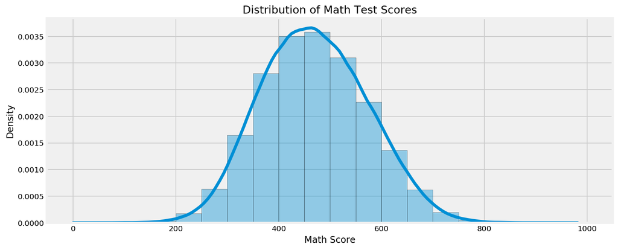

```python
scoreDistVis()
```

## Feelings of anxiety

The following reviews of student answers regarding anxiety makes it clear that students struggle with math anxiety, worry that it is difficult, and they will not receive good grades.

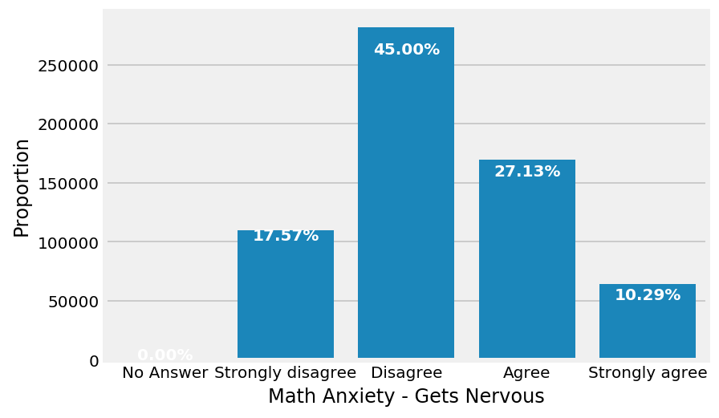

```python
plotCat(pisa_df.query('ma_get_nervous != "No Answer"'),'ma_get_nervous','Proportion','Math Anxiety - Gets Nervous')
```

## ~38% of students report math makes them nervous.

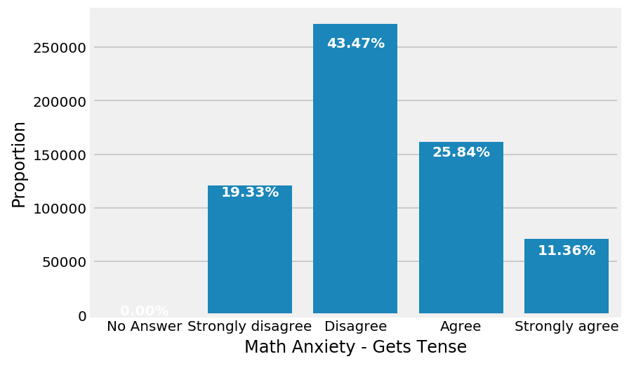

```python
plotCat(pisa_df.query('ma_get_tense != "No Answer"'),'ma_get_tense','Proportion','Math Anxiety - Gets Tense')
```

## 37% of students report math makes them tense.

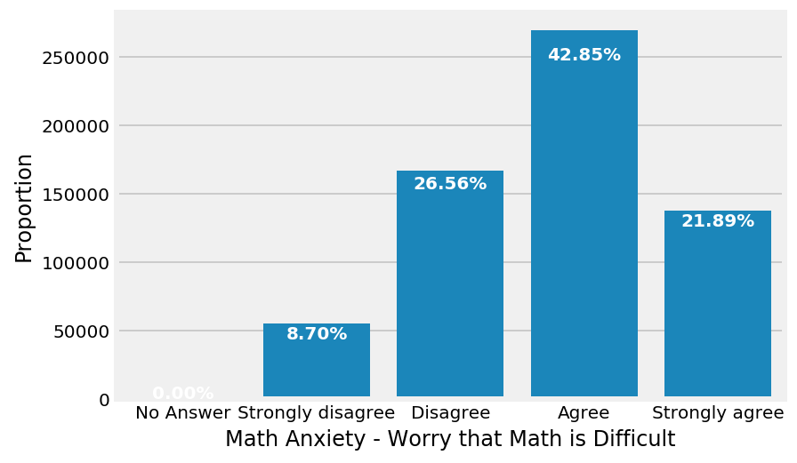

```python
plotCat(pisa_df.query('ma_worry_that_difficult != "No Answer"'),'ma_worry_that_difficult','Proportion',
        'Math Anxiety - Worry that Math is Difficult')
```

## Almost 65% of the students reported worrying that math was too difficult.

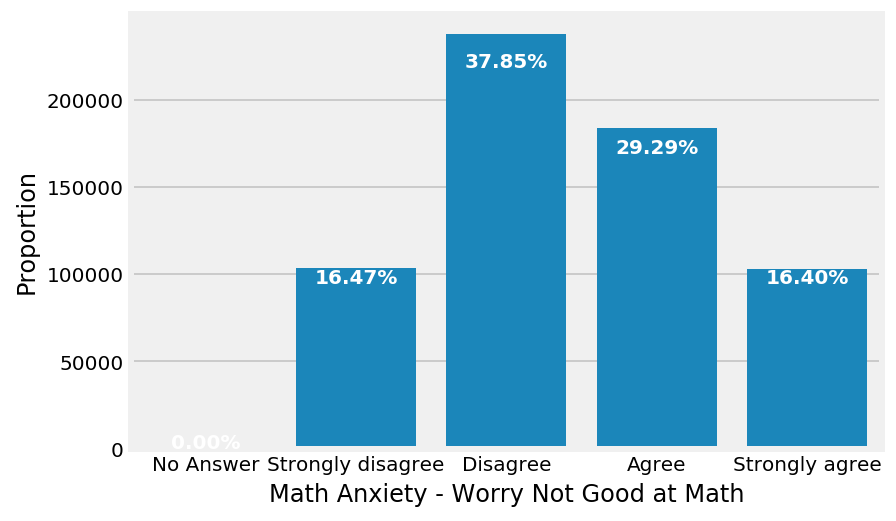

```python
plotCat(pisa_df.query('msc_worry_not_good_at != "No Answer"'),'msc_worry_not_good_at','Proportion',
        'Math Anxiety - Worry Not Good at Math')
```

## ~46% of students worried they are not good at math.

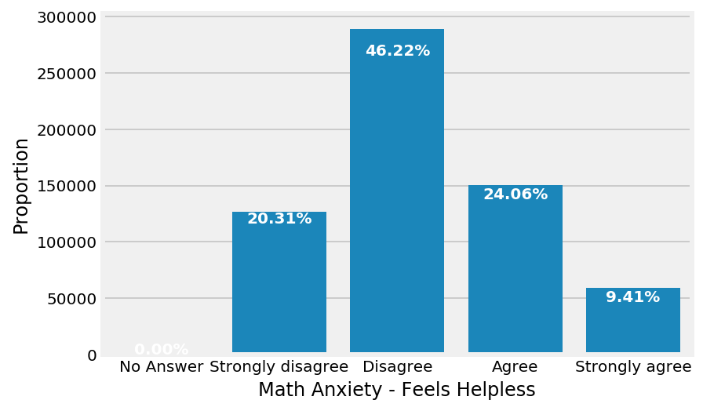

```python
plotCat(pisa_df.query('ma_feel_helpless != "No Answer"'),'ma_feel_helpless','Proportion',
        'Math Anxiety - Feels Helpless')
```

## 33% of students reported that math made them feel helpless.

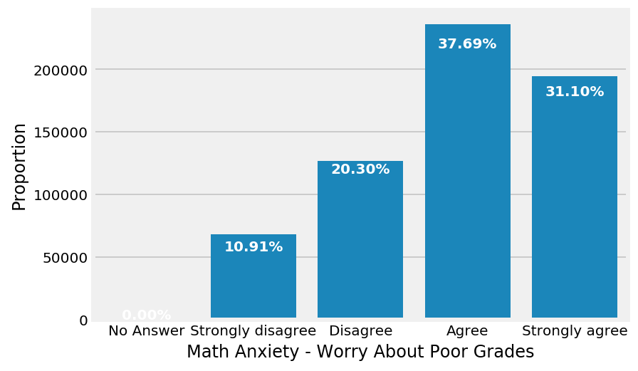

```python
plotCat(pisa_df.query('ma_worry_about_poor_grades != "No Answer"'),'ma_worry_about_poor_grades','Proportion',
        'Math Anxiety - Worry About Poor Grades')
```

## ~69% of students worried about getting good grades in math.

## As we start to look at the correlation between the students feelings of anxiety and the scores it becomes apparent that the students feeling the most anxiety have lower scores

```python
def vioplot(data, x, y, ylabel='', xlabel='',inner=None, title=None):
    # use the supplied dataframe to generate a violin chart of values
    base_color = sb.color_palette()[0]
    sb.violinplot(data=data, x=x, y=y, color=base_color, inner=inner)

    plt.xlabel(xlabel);
    plt.ylabel(ylabel);

    if title:
        plt.title(title);

    return
```

```python
def bxplot(data, x, y, ylabel='', xlabel='', title=None):
    # use the supplied dataframe to generate a boxplot chart of values
    base_color = sb.color_palette()[0]
    sb.boxplot(data=data, x=x, y=y, color=base_color)

    plt.xlabel(xlabel);
    plt.ylabel(ylabel);

    if title:
        plt.title(title);

    return
```

```python
def barplot(data, x, y, ylabel='', xlabel='', title=None):
    # use the supplied dataframe to generate a barplot chart of values
    base_color = sb.color_palette()[0]
    ax = sb.countplot(data=data,x=x, hue=y, color=base_color);
    ax.legend(loc=2, ncol=5, framealpha=1);

    plt.xlabel(xlabel);
    plt.ylabel(ylabel);

    if title:
        plt.title(title);

    return
```

```python
def mbarplot(data, x, y, cvar, ylabel='', xlabel='', title=None):
    # use the supplied dataframe to generate a barplot
    # chart of multiple values - for multivariate plots
    ax = sb.barplot(data=data,x=x, y=y, hue=cvar);
    ax.legend(loc=8, ncol=2, framealpha=1);

    # add annotations
    bars = ax.patches
    half = int(len(bars)/2)
    left_bars = bars[:half]
    right_bars = bars[half:]

    for left, right in zip(left_bars, right_bars):
        height_l = left.get_height()
        height_r = right.get_height()
        total = height_l + height_r

        ax.text(left.get_x() + (left.get_width()-.05)/2., height_l + 15, '{0:.1%}'.format(height_l/total), ha="center")
        ax.text(right.get_x() + (right.get_width()+.05)/2., height_r + 25, '{0:.1%}'.format(height_r/total), ha="center")

    plt.xlabel(xlabel);
    plt.ylabel(ylabel);

    if title:
        plt.title(title);

    return
```

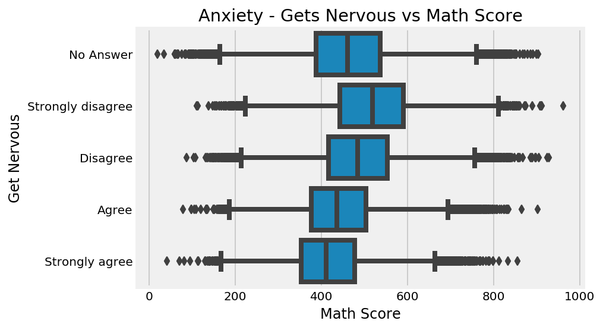

```python
bxplot(pisa_df, 'math_score', 'ma_get_nervous', 'Get Nervous', 'Math Score', 'Anxiety - Gets Nervous vs Math Score');
```

## The students reporting being the most nervous have lower scores.

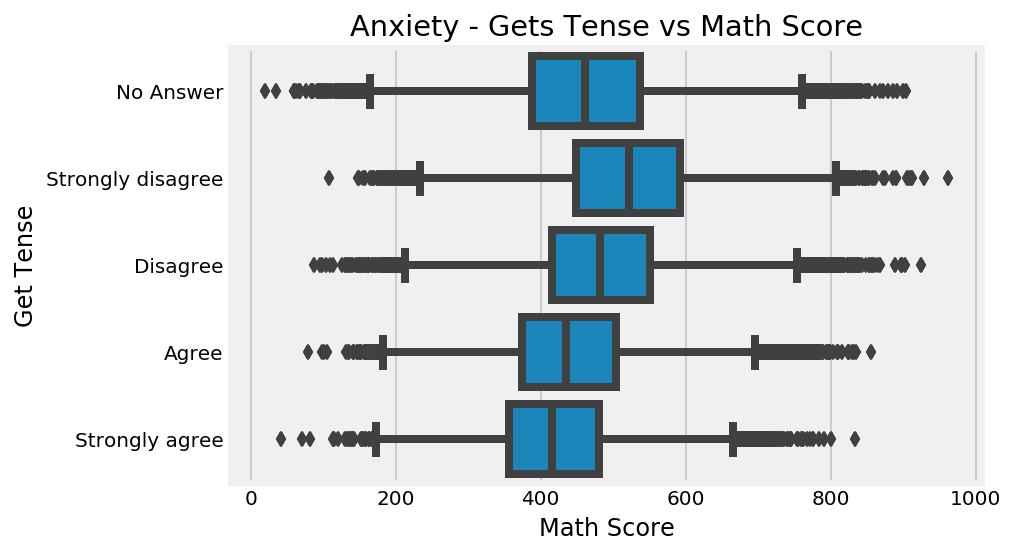

```python
bxplot(pisa_df, 'math_score', 'ma_get_tense', 'Get Tense', 'Math Score', 'Anxiety - Gets Tense vs Math Score');
```

## Students reporting a higher degree of tenseness have lower scores.

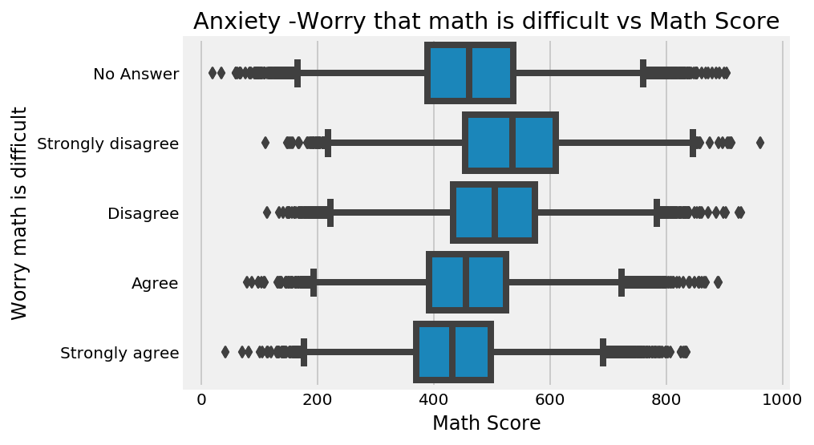

```python
bxplot(pisa_df, 'math_score', 'ma_worry_that_difficult', 'Worry math is difficult',
       'Math Score', 'Anxiety -Worry that math is difficult vs Math Score');
```

## Students reporting more worry about the difficulty of math have lower scores.

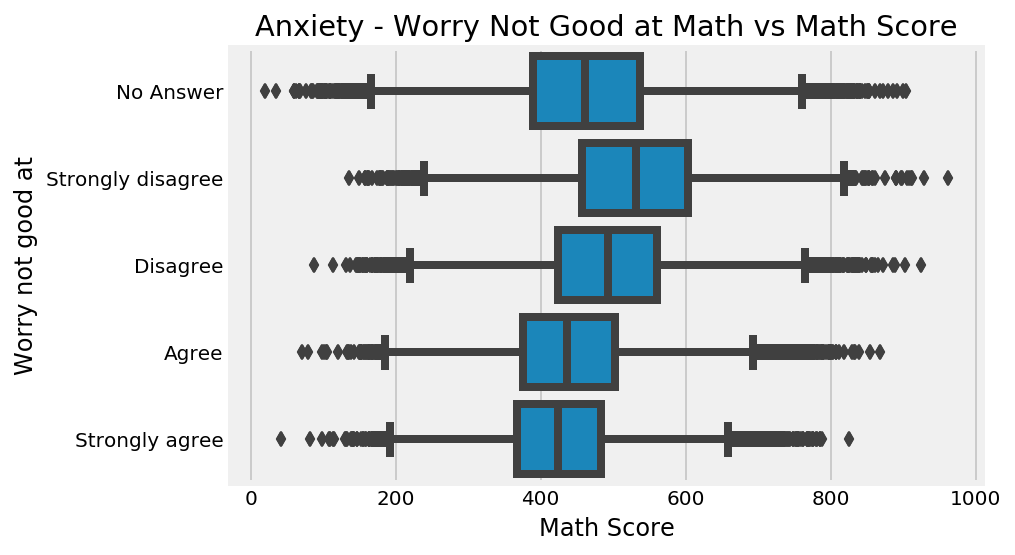

```python
bxplot(pisa_df, 'math_score', 'msc_worry_not_good_at', 'Worry not good at',
       'Math Score', 'Anxiety - Worry Not Good at Math vs Math Score');
```

## Students worried they are not good at math have lower scores.

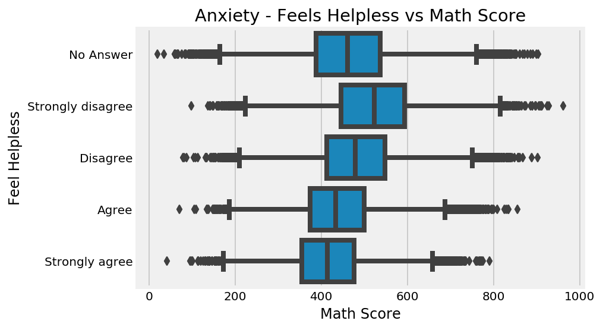

```python
bxplot(pisa_df, 'math_score', 'ma_feel_helpless', 'Feel Helpless',
       'Math Score', 'Anxiety - Feels Helpless vs Math Score');
```

## Students reporting math makes them feel helpless have lower scores.

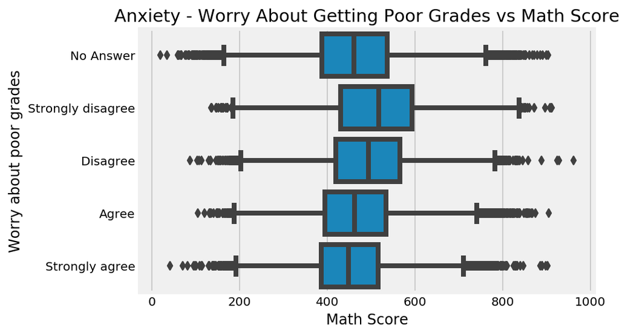

```python
bxplot(pisa_df, 'math_score', 'ma_worry_about_poor_grades', 'Worry about poor grades',
       'Math Score', 'Anxiety - Worry About Getting Poor Grades vs Math Score');
```

## Students who report they worry about poor grades in math have lower scores.

## Examining if males or females are reporting anxiety, and if it is impacting the test scores, shows that males are slightly more positive about not feeling anxiety. It still remains evident that students reporting less feelings of anxiety about math are scoring higher than those that do report anxiety.

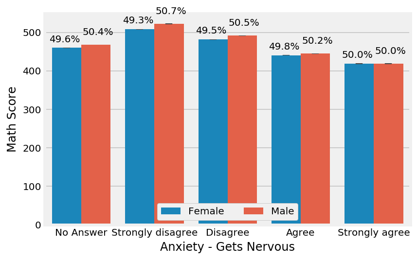

```python
mbarplot(pisa_df, 'ma_get_nervous' , 'math_score', 'gender', 'Math Score', 'Anxiety - Gets Nervous')
```

## Males and Females reporting math nervousness have lower scores.

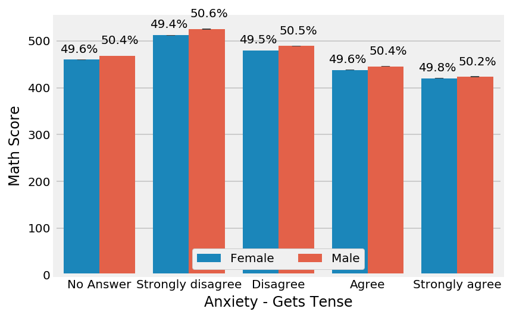

```python
mbarplot(pisa_df, 'ma_get_tense', 'math_score', 'gender', 'Math Score', 'Anxiety - Gets Tense')
```

## Males and Females reporting math tenseness have lower scores.

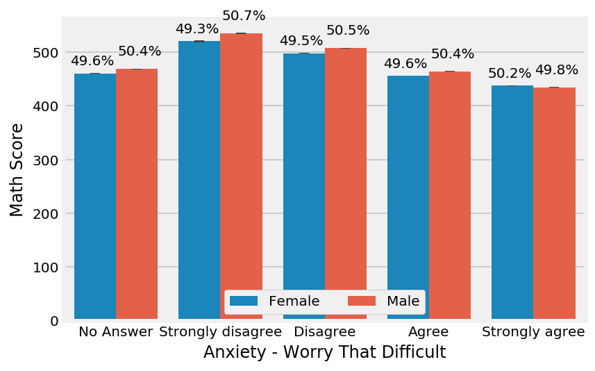

```python
mbarplot(pisa_df, 'ma_worry_that_difficult', 'math_score', 'gender', 'Math Score',
         'Anxiety - Worry That Difficult')
```

## Males and Females worrying about math difficulty have lower scores.

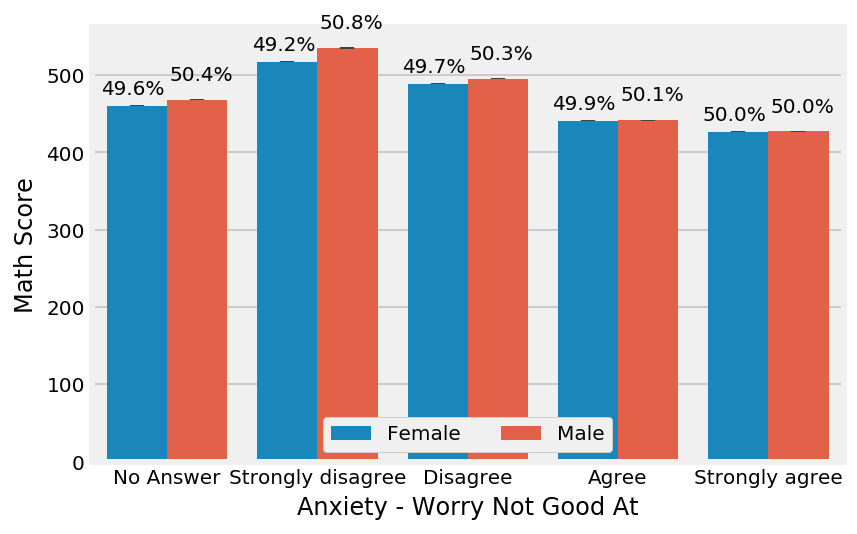

```python
mbarplot(pisa_df, 'msc_worry_not_good_at', 'math_score', 'gender', 'Math Score',
         'Anxiety - Worry Not Good At')
```

## Males and Females reporting they are not good at math have lower scores.

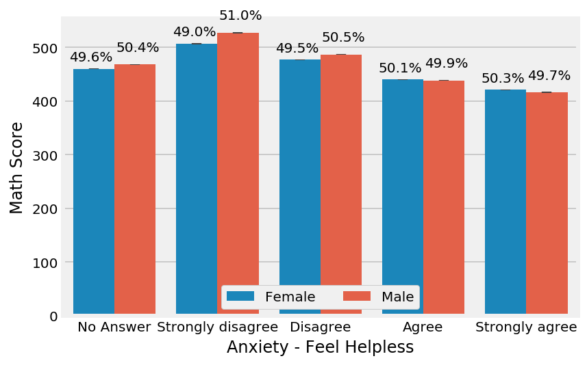

```python
mbarplot(pisa_df, 'ma_feel_helpless', 'math_score', 'gender', 'Math Score',
         'Anxiety - Feel Helpless')
```

## Males and Females reporting math makes them feel helpless have lower scores.

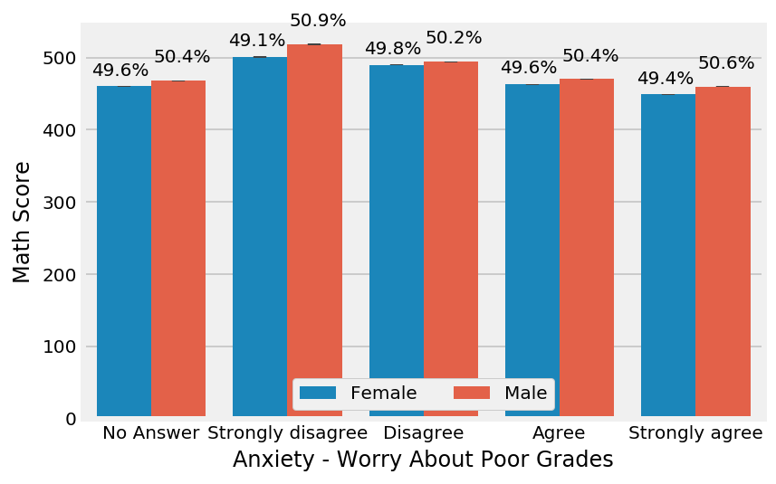

```python
mbarplot(pisa_df, 'ma_worry_about_poor_grades', 'math_score', 'gender','Math Score',
         'Anxiety - Worry About Poor Grades')
```

## Males and Females worrying about poor grades in math have lower scores.

### It seems that a student's feelings of anxiety and self-doubt in their mathmatical ability does correlate to test scores achieved. Males are slightly more more positve about their math ability and lessened anxiety and do have slightly higher scores than their female classmates. It's beyond the scope of this investigation but cultural biases probably play a part in males feeling better about themselves in relation to math.